# Storm Data Project

##### How To Handle Values of PROPDMGEXP and CROPDMGEXP

```r
#check the unique values of PROPDMGEXP and CROPDMGEXP
unique(subset_stormdata$PROPDMGEXP)
```

```
##  [1] "K" "M" ""  "B" "m" "+" "0" "5" "6" "?" "4" "2" "3" "h" "7" "H" "-" "1" "8"
```

```r
unique(subset_stormdata$CROPDMGEXP)
```

```
## [1] ""  "M" "K" "m" "B" "?" "0" "k" "2"
```

- After doing some research, reading the NOAA storm data documentation, and direction from the RPubs publication [*How To Handle Exponent Value of PROPDMGEXP and CROPDMGEXP*](https://rstudio-pubs-static.s3.amazonaws.com/58957_37b6723ee52b455990e149edde45e5b6.html), I have determined that the coded values in the PROPDMGEXP AND CROPDMGEXP values are multipliers for the data
- *Note: EXP = exponent*
- *Note: any numeric value that is not 1 and 0 (2;3;4;5;6;7;8) is believed to be improper handling in the dataset that was later fixed in a 2012 update. The error is that those numbers were intended to be the ones digit in the corresponding PROPDMG and CROPDMG values. This would make each PROPDMG and CROPDMG value with a corresponding CROPDMGEXP and PROPDMGEXP value to be approximately 10x the reported value. Therefore, those numbers will be a multiplier of ten*

```r
#convert PROPDMGEXP and CROPDMGEXP values and multiply PROPDMG by PROPDMGEXP and amd CROPDMG by CROPDMGEXP
subset_stormdata$PROPDMGEXP[is.na(subset_stormdata$PROPDMGEXP)] <- 0
subset_stormdata$PROPDMGEXP[subset_stormdata$PROPDMGEXP == ""] <- 1
subset_stormdata$PROPDMGEXP[grep("[-+?]", subset_stormdata$PROPDMGEXP)] <- 1
subset_stormdata$PROPDMGEXP[grep("[2-8]", subset_stormdata$PROPDMGEXP)] <- 10
subset_stormdata$PROPDMGEXP[grep("[Hh]", subset_stormdata$PROPDMGEXP)] <- 100
subset_stormdata$PROPDMGEXP[grep("[Kk]", subset_stormdata$PROPDMGEXP)] <- 1000
subset_stormdata$PROPDMGEXP[grep("[Mm]", subset_stormdata$PROPDMGEXP)] <- 1000000
subset_stormdata$PROPDMGEXP[grep("[Bb]", subset_stormdata$PROPDMGEXP)] <- 1000000000

subset_stormdata$CROPDMGEXP[is.na(subset_stormdata$CROPDMGEXP)] <- 0
subset_stormdata$CROPDMGEXP[subset_stormdata$CROPDMGEXP == ""] <- 1
subset_stormdata$CROPDMGEXP[grep("[?]", subset_stormdata$CROPDMGEXP)] <- 1
subset_stormdata$CROPDMGEXP[grep("[2]", subset_stormdata$CROPDMGEXP)] <- 10
subset_stormdata$CROPDMGEXP[grep("[Hh]", subset_stormdata$CROPDMGEXP)] <- 100
subset_stormdata$CROPDMGEXP[grep("[Kk]", subset_stormdata$CROPDMGEXP)] <- 1000
subset_stormdata$CROPDMGEXP[grep("[Mm]", subset_stormdata$CROPDMGEXP)] <- 1000000
subset_stormdata$CROPDMGEXP[grep("[Bb]", subset_stormdata$CROPDMGEXP)] <- 1000000000

#check unique values again
unique(subset_stormdata$PROPDMGEXP)
```

```
## [1] "1000"  "1e+06" "1"     "1e+09" "0"     "10"    "100"
```

```r
unique(subset_stormdata$CROPDMGEXP)
```

```
## [1] "1"     "1e+06" "1000"  "1e+09" "0"     "10"
```

```r
#create new columns for property damage and crop damage and change PROPDMGEXP and CROPDMGEXP to numeric and multiply with PROPDMG and CROPDMG and put into new columsn
subset_stormdata$PROPDMGEXP <-as.numeric(subset_stormdata$PROPDMGEXP)
subset_stormdata$Property.Damage <- subset_stormdata$PROPDMG * subset_stormdata$PROPDMGEXP
subset_stormdata$CROPDMGEXP <-as.numeric(subset_stormdata$CROPDMGEXP)
subset_stormdata$Crop.Damage <- subset_stormdata$CROPDMG * subset_stormdata$CROPDMGEXP

#combine property and crop damage to be a colummn containing total damage
subset_stormdata$Total.Damage <- subset_stormdata$Crop.Damage + subset_stormdata$Property.Damage
```

```r
#I want to subset my data and change column names for sake of clarity
stormdata_final <- subset_stormdata[, c("EVTYPE", "FATALITIES", "INJURIES", "Total.Damage")]
colnames(stormdata_final) <- c("Event.Type", "Fatalities", "Injuries", "Total.Damage")
```

##### Calculate the sum of each column and order it in descending order

```r
sum_fatalities <- aggregate(Fatalities ~ Event.Type, stormdata_final, sum)
sum_fatalities <- sum_fatalities[order(-sum_fatalities$Fatalities),c(1,2)]

sum_injuries <- aggregate(Injuries ~ Event.Type, stormdata_final, sum)
sum_injuries <- sum_injuries[order(-sum_injuries$Injuries),c(1,2)]

sum_totaldamage <- aggregate(Total.Damage ~ Event.Type, stormdata_final, sum)
sum_totaldamage <-sum_totaldamage[order(-sum_totaldamage$Total.Damage),c(1,2)]
```

##### Get top 10 most harmful in terms of fatalities, injuries, and economic damage

```r
#subset top 10
top10_fatalities <- sum_fatalities[1:10,]
top10_injuries <- sum_injuries[1:10,]
top10_damage <- sum_totaldamage[1:10,]
```

### Results

1. Across the United States, which types of events (as indicated in the EVTYPE variable) are most harmful with respect to population health?

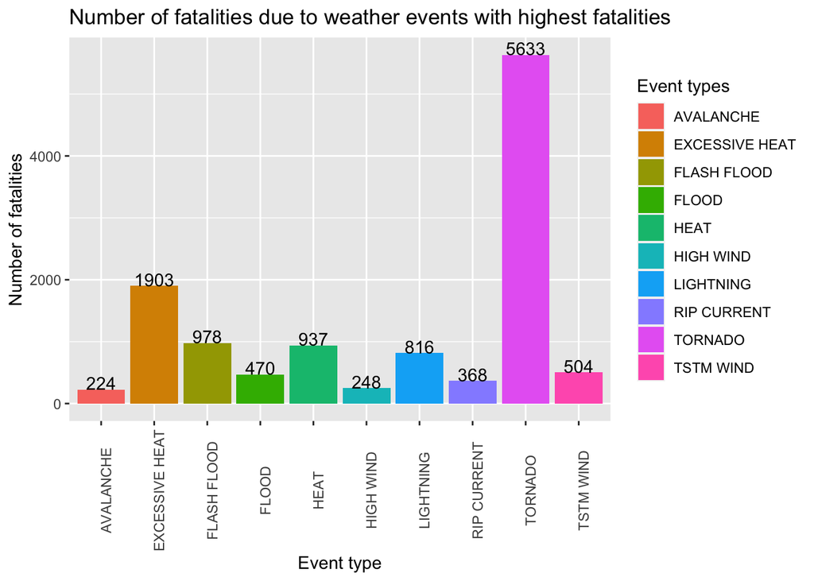

```r
library(ggplot2)

ggplot(top10_fatalities, aes(x = Event.Type, y = Fatalities, fill = Event.Type, label =Fatalities)) +
geom_bar(stat = "identity") +
labs(x = "Event type", y = "Number of fatalities", fill = "Event types") +
ggtitle("Number of fatalities due to weather events with highest fatalities") +
geom_text(aes(label = Fatalities),vjust=0) +
theme(axis.text.x = element_text(angle = 90))
```

**Tornados cause the highest number of fatalities among all severe weather types since 1950 to November 2011.**

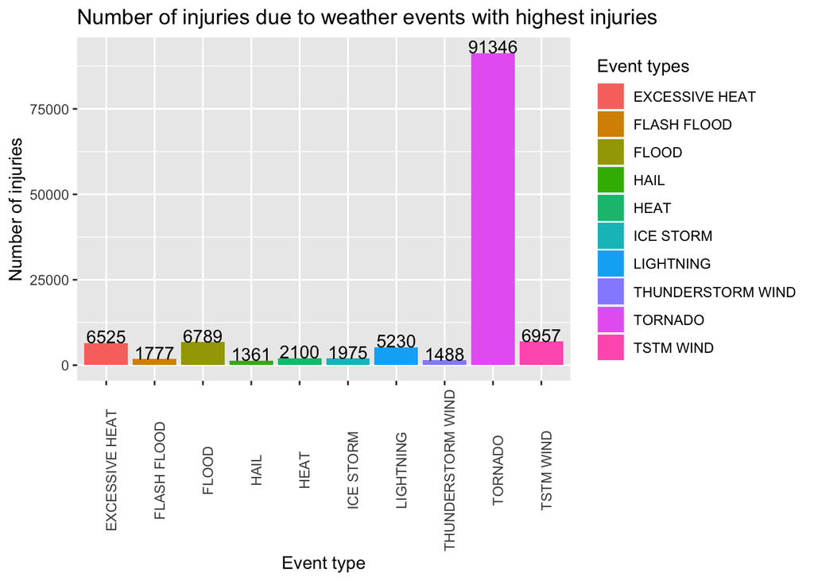

```r
library(ggplot2)

ggplot(top10_injuries, aes(x = Event.Type, y = Injuries, fill = Event.Type, label =Injuries)) +
geom_bar(stat = "identity") +
labs(x = "Event type", y = "Number of injuries", fill = "Event types") +
ggtitle("Number of injuries due to weather events with highest injuries") +
geom_text(aes(label = Injuries),vjust=0) +
theme(axis.text.x = element_text(angle = 90))
```

**Tornados cause the highest number of injuries among all severe weather types since 1950 to November 2011.**

2. Across the United States, which types of events have the greatest economic consequences?

[figure not shown]

```r
library(ggplot2)

ggplot(top10_damage, aes(x = Event.Type, y = Total.Damage/1000000000, fill = Event.Type, label =Total.Damage/1000000000)) +
geom_bar(stat = "identity") +
labs(x = "Event type", y = "Economic damage in trillions of dollars", fill = "Event types") +
ggtitle("Economic damage due to weather events with highest economic damage") +
geom_text(aes(label = round(Total.Damage/1000000000,2)),vjust=0) +
theme(axis.text.x = element_text(angle = 90))
```

**Floods have caused the highest economic damange (property and crop damage) among all severe weather types since 1950 to November 2011.**